# HW1 Problem3 (BDA Chap2 problem11)

**Computing with a nonconjugate single parameter model: suppose $y_1,...,y_5$ are independent samples from a Cauchy distribution with unknown center $\theta$ and known scale 1: $p(y_i|\theta) \propto 1/(1+(y_i - \theta)^2)$. Assume, for simplicity, that the prior distribution fonr $\theta$ is uniform on $[0,100]$. Given the observations $(y_1,...,y_5)=(43, 44, 45, 46.5, 47.5)$:**

*python script: hw1prob3.py*

```python
from math import log, exp, pi, tan
from random import choices, random, seed
from statistics import mean, median, variance

import matplotlib.pyplot as plt

seed(20220402)
observations = [43, 44, 45, 46.5, 47.5]
```

Note that our posterior distribution is $p(\theta|y) \propto (\frac{1}{1+(y_i-\theta)^2})^5 \frac{1}{100} I_{\theta \in [0, 100]}(\theta)$

## 3-(a)

**Compute the unnormalized posterior denstiy function $p(\theta)p(y|\theta)$ on a grid of points $\theta=0,1/m,2/m,...,100$, for some large integer m.** **Using the grid approximation, compute and plot the normalized posterior density function, $p(\theta|y)$, as a function of $\theta$.**

I will make a grid with $m=1000$ and calculate posterior distribution values over the grid. After normalizing it using the sum of all unnormalized posterior values on that grid (as an approximated nomalizing constant), I will report a plot to sketch the posterior.

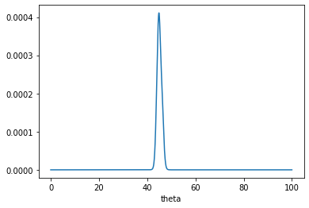

```python
# draw posterior samples using grid approximation
def unnormalized_cauchy_log_pdf(eval_pt, location, scale=1):
    denom = 1+((eval_pt-location)/scale)**2
    return -log(denom)

m = 1000
grid = [i/m for i in range(0, 100*m)]
grid.append(100)
posterior_on_grid = []

for grid_pt in grid:
    obs_log_likelihood = [unnormalized_cauchy_log_pdf(obs, grid_pt) for obs in observations]
    log_posterior_val = sum(obs_log_likelihood) - 2
    posterior_on_grid.append(exp(log_posterior_val))

posterior_normalizer_on_grid = sum(posterior_on_grid)
posterior_on_grid = [val / posterior_normalizer_on_grid for val in posterior_on_grid]

# show (part of a)
plt.plot(grid, posterior_on_grid)
plt.xlabel("theta")
plt.show()
```

The posterior mass is concentrated near 45. This seems reasonable, cause we used uniform prior which can be regarded as a vague prior and given data points are around 45.

## 3-(b)

**Sample 1000 draws of $\theta$ from the posterior density and plot a histogram of the draws.**

Since we already construct a (approximated) posterior on grid, we can get sample directly using that grid. Python 'choices' function, which is the same as 'sample' function in R, gives us a convenient way to pick a grid point using posterior probability as a weight. We can think a chosen grid point as a posterior sample.

```
==posterior==
mean: 45.049
median: 45.019
variance: 0.963
```

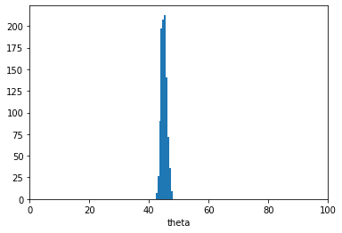

```python
# posterior draws (part of b)
posterior_samples_from_grid = choices(grid, posterior_on_grid, k=1000)
print("==posterior==")
print("mean:", round(mean(posterior_samples_from_grid), 3))
print("median:", round(median(posterior_samples_from_grid), 3))
print("variance:", round(variance(posterior_samples_from_grid), 3))
plt.hist(posterior_samples_from_grid, bins=10)
plt.xlabel("theta")
plt.xlim([0,100])
plt.show()
```

Above outputs show a histogram of samples drawn from the grid and some summary statistics. The shape consists with the plot in (a), so we can think that sampling is well done.

## 3-(c)

Use the 1000 samples of $\theta$ to obtain 1000 samples from the predictive distribution of a future observation, $y_6$, and plot a histogram of the predictive draws.

We can draw predictive samples using posterior sample and the data-generating model (likelihood) given by the problem. In detail, because $y_i|\theta \sim Cauchy(\theta, 1)$, we can draw a cauchy sample under each realized posterior sample for a new point $y_6$, under the assumption that $y_6$ is conditionally independent to $y_1,...,y_5$ if $\theta$ is given.

Here, I will use the inverse CDF method to draw cauchy sample, since its CDF form is easy to deal with.

```
==posterior predictive==
mean: 43.22
median: 44.957
variance: 681.795
```

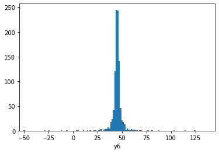

```python
# posterior predictive draws (part of c)
def cauchy_inverse_cdf(eval_prob, location, scale=1):
    quantile_val = location +  scale * tan(pi*(eval_prob-0.5))
    return quantile_val

predictive_samples = [cauchy_inverse_cdf(random(), loc) for loc in posterior_samples_from_grid]
print("==posterior predictive==")
print("mean:", round(mean(predictive_samples),3))
print("median:", round(median(predictive_samples),3))
print("variance:", round(variance(predictive_samples),3))
plt.hist(predictive_samples, bins=500)
plt.xlabel("y6")
plt.xlim([45-100, 45+100])
plt.show()
```

The outputs are a histogram of drawn predictive samples and some summaries over these samples, even if considering moments for cauchy distribution's samples is a little bit nonsense though (theoretically even population's first moment does not exist). From the histogram, we can found that the center is again around 45, which is the location parameter's mean. Moreover, it has very long tail, which is a characteristic of the Cauchy distribution.